# Introduction

# Tidyverse and plotting

The function ‘ggplot’ is used for data visualization - it creates a graph. The function ‘geom_point’ tells R you want to create a plot of points. ‘data = snow_deaths’ tells R you want to use the ‘snow_deaths’ dataframe. ‘aes’ stands for aesthetics of your graph where ‘x = long’ sets the x axis to ‘long’, where ‘y = lat’ sets the y axis to ‘lat’, where ‘color = blue’ colours the points blue and ‘shape = 16’ assigns the shape of the points - in this case, ‘16’ are circles and ‘17’ are triangles

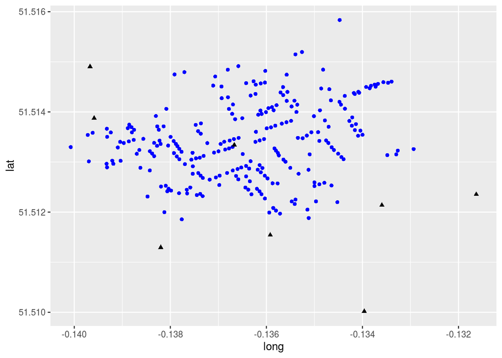

```r
ggplot() +
  geom_point(data = snow_deaths, aes(x = long, y = lat), color = "blue", shape = 16) +
  geom_point(data = snow_pumps, aes(x = long, y = lat), color = "black", shape = 17)
```

# Vector data with sf

sf is an implementation of Simple features, an open standard developed and endorsed by the Open Geospatial Consortium (OGC).

The big difference between sf and sp is that sf uses S3 classes rather than S4 as sp does. Simple features are simple data.frame objects that have a geometry list-column. The simple feature model will be familiar to those who use PostGIS, MySQL Spatial Extensions, Oracle Spatial, the OGR component of the GDAL p_load, GeoJSON and GeoPandas in Python.

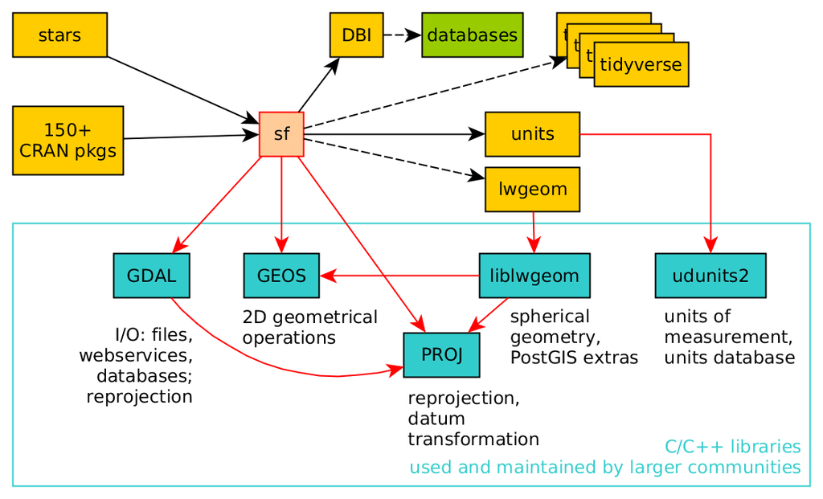

```r
knitr::include_graphics("./figure/sf_deps.png")
```

```r
p_load(sf)
methods(class = 'sf')
```

```
##  [1] [                     [[<-                  $<-
##  [4] aggregate             anti_join             arrange
##  [7] as.data.frame         cbind                 coerce
## [10] dbDataType            dbWriteTable          distinct
## [13] dplyr_reconstruct     filter                full_join
## [16] gather                group_by              group_split
## [19] identify              initialize            inner_join
## [22] left_join             merge                 mutate
## [25] nest                  plot                  print
## [28] rbind                 rename                right_join
## [31] rowwise               sample_frac           sample_n
## [34] select                semi_join             separate_rows
## [37] separate              show                  slice
## [40] slotsFromS3           spread                st_agr
## [43] st_agr<-              st_area               st_as_s2
```

[output cut: 19 more lines]

# Geoprocessing

```r
p_load(sf)
p_load(tigris)
p_load(tmap)
```

```r
counties <- counties("Texas", cb = TRUE)
counties<-st_as_sf(counties)
counties$area <- as.numeric(st_area(counties))
glimpse(counties)
```

```
## Rows: 254
## Columns: 11
## $ STATEFP  <chr> "48", "48", "48", "48", "48", "48", "48", "48", "48", "48", …
## $ COUNTYFP <chr> "081", "273", "203", "223", "033", "419", "067", "025", "339…
## $ COUNTYNS <chr> "01383826", "01383922", "01383887", "01383897", "01383802", …
## $ AFFGEOID <chr> "0500000US48081", "0500000US48273", "0500000US48203", "05000…
## $ GEOID    <chr> "48081", "48273", "48203", "48223", "48033", "48419", "48067…
## $ NAME     <chr> "Coke", "Kleberg", "Harrison", "Hopkins", "Borden", "Shelby"…
## $ LSAD     <chr> "06", "06", "06", "06", "06", "06", "06", "06", "06", "06", …
## $ ALAND    <dbl> 2361153195, 2282572445, 2331138836, 1987629163, 2324366073, …
## $ AWATER   <dbl> 42331832, 541041659, 40651525, 65639829, 22297606, 101081674…
## $ geometry <MULTIPOLYGON [°]> MULTIPOLYGON (((-100.825 31..., MULTIPOLYGON ((…
## $ area     <dbl> 2403009205, 2351728709, 2371860830, 2053237899, 2346696392, …
```

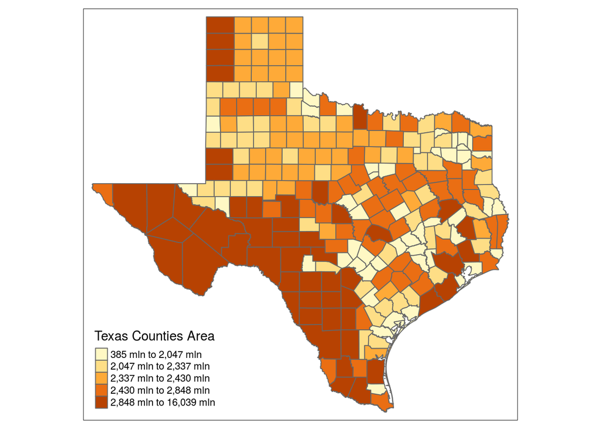

```r
tm_shape(counties) +
  tm_polygons("area",
              style="quantile",
              title="Texas Counties Area")
```

```r
#p_load(mapview)
#mapview(tex_cap, col="red", col.regions = "red") + mapview(counties, alpha.regions = .1)
```

Typical topological operations

# Spatial Subsetting

```r
 counties[NAME="Houston",]
```

```
## Simple feature collection with 254 features and 10 fields
## geometry type:  MULTIPOLYGON
## dimension:      XY
## bbox:           xmin: -106.6456 ymin: 25.83738 xmax: -93.50829 ymax: 36.5007
## CRS:            4269
## First 10 features:
##     STATEFP COUNTYFP COUNTYNS       AFFGEOID GEOID       NAME LSAD      ALAND
## 1        48      081 01383826 0500000US48081 48081       Coke   06 2361153195
## 2        48      273 01383922 0500000US48273 48273    Kleberg   06 2282572445
## 3        48      203 01383887 0500000US48203 48203   Harrison   06 2331138836
## 4        48      223 01383897 0500000US48223 48223    Hopkins   06 1987629163
## 5        48      033 01383802 0500000US48033 48033     Borden   06 2324366073
## 6        48      419 01383995 0500000US48419 48419     Shelby   06 2060566172
## 7        48      067 01383819 0500000US48067 48067       Cass   06 2426730190
## 8        48      025 01383798 0500000US48025 48025        Bee   06 2279809490
## 124      48      339 01383955 0500000US48339 48339 Montgomery   06 2699517016
## 125      48      029 01383800 0500000US48029 48029      Bexar   06 3212379601
##        AWATER                       geometry       area
## 1    42331832 MULTIPOLYGON (((-100.825 31... 2403009205
## 2   541041659 MULTIPOLYGON (((-97.3178 27... 2351728709
## 3    40651525 MULTIPOLYGON (((-94.70215 3... 2371860830
## 4    65639829 MULTIPOLYGON (((-95.86333 3... 2053237899
## 5    22297606 MULTIPOLYGON (((-101.6913 3... 2346696392
## 6   101081674 MULTIPOLYGON (((-94.51143 3... 2161887310
## 7    60494083 MULTIPOLYGON (((-94.65384 3... 2487418192
## 8      246409 MULTIPOLYGON (((-98.08976 2... 2280198442
## 124  89546861 MULTIPOLYGON (((-95.83024 3... 2789115377
## 125  40835789 MULTIPOLYGON (((-98.80655 2... 3253364803
```

# Dissolve

```r
counties %>%
  group_by(STATEFP) %>%
  summarise(area = sum(area))
```

```
## although coordinates are longitude/latitude, st_union assumes that they are planar
```

```
## Simple feature collection with 1 feature and 2 fields
## geometry type:  MULTIPOLYGON
## dimension:      XY
## bbox:           xmin: -106.6456 ymin: 25.83738 xmax: -93.50829 ymax: 36.5007
## CRS:            4269
## # A tibble: 1 x 3
##   STATEFP        area                                                   geometry
##   <chr>         <dbl>                                         <MULTIPOLYGON [°]>
## 1 48          6.88e11 (((-97.25287 26.3753, -97.2505 26.37509, -97.24955 26.373…
```

# Visualizing Spatial Data

```r
# 'Leaflet' is a package used for visualizing data on a map in R. 'Magrittr' is a package used for creating pipe operators
#install.packages('leaflet') # Run only if you have not yet installed `leaflet`!
#install.packages('magrittr') # Run only if you have not yet installed `magrittr`!
p_load(leaflet)
p_load(magrittr)

# Here, we create a `leaflet` object and assign it to the variable, 'm'. The 'setView' function sets the view of the map where 'lng = -0.136' sets the longitutde, 'lat = 51.513' sets the latitude and the map zoom is set to 16. The '%>%' is a pipe operator that passes the output from the left hand side of the operator to the first argument of the right hand side of the operator. In this case we are telling `R` that we want to center the map on the set longitude and latitude, with a zoom level of 16, which corresponds roughly to a neighborhood

m <- leaflet(data = snow_deaths) %>%
  setView(lng = -0.136, lat = 51.513, zoom = 16)
```

# Leaflet

```r
#The map is empty! This is because we have not yet added any geographical information to plot. We can begin by adding a basemap as follows:

# We are adding a basemap or background map of the study location by means of the `addTiles` function to the 'm' variable
m <- m %>% addTiles()
m
```

[interactive chart not shown]

# Visualization

The map now shows the neighborhood in Soho where the cholera outbreak happened. Now, at long last, we can add the cases of cholera deaths to the map. For this, we indicate the coordinates (preceded by ~), and set an option for clustering by means of the clusterOptions in the following fashion:

We are adding the cholera deaths to the map using ‘group = Deaths’. The ‘~’ symbol tells R to use the same longitude and latitude values used in the previous block of code and the ‘clusterOptions = markerClusterOptions()’ clusters a large number of markers on the map - in this case it is clusturing number of deaths into icons with numbers

```r
m <- m %>% addMarkers(~long, ~lat, clusterOptions = markerClusterOptions(), group = "Deaths")
m
```

[interactive chart not shown]

The map now displays the locations of cholera deaths on the map. If you zoom in, the clusters will rearrange accordingly. Try it! The other information that we have available is the location of the water pumps, which we can add to the map above (notice that the Broad Street Pump is already shown in the basemap!):

```r
m %>% addMarkers(data = snow_pumps, ~long, ~lat, group = "Pumps")
```

[interactive chart not shown]

An alternative and quicker way to run the same bit of code is by means of pipe operators (%>%). These operators make writing code a lot faster, easier to read, and more intuitive! Recall that a pipe operator will take the output of the preceding function, and pass it on as the first argument of the next:

```r
m_test <- leaflet () %>%
  setView(lng = -0.136, lat = 51.513, zoom = 16) %>%
  addTiles() %>%
  addMarkers(data = snow_deaths, ~long, ~lat, clusterOptions = markerClusterOptions(), group = "Deaths") %>%
  addMarkers(data = snow_pumps, ~long, ~lat, group = "Pumps")
m_test
```

[interactive chart not shown]

```r
p_load(leaflet.extras)
m2 <- leaflet(data = snow_deaths) %>%
  setView(lng = -0.136, lat = 51.513, zoom = 16) %>%
  addTiles()
```

```r
# The 'addHeatmap' function is making a heat map. We specify the coordinates, same as the block of code above. The 'intensity' function sets a numeric value, the 'blur' specifies the amount of blur to apply and the 'radius' function sets the radius of each point on the heatmap
m2 %>% addHeatmap(lng = ~long, lat = ~lat, intensity = ~Count,
             blur = 40, max = 1, radius = 25)
```

[interactive chart not shown]

```r
#Lastly, you can also add markers for the pumps as follows:

m2 %>% addHeatmap(lng = ~long, lat = ~lat, intensity = ~Count,
                  blur = 40, max = 1, radius = 25) %>%
  addMarkers(data = snow_pumps, ~long, ~lat, group = "Pumps")
```

[interactive chart not shown]

```r
#And everything together:


m2_test <- leaflet(data = snow_deaths) %>%
  setView(lng = -0.136, lat = 51.513, zoom = 16) %>%
  addTiles() %>%
  addHeatmap(lng = ~long, lat = ~lat, intensity = ~Count,blur = 40, max = 1, radius = 25) %>%
  addMarkers(data = snow_deaths, ~long, ~lat, clusterOptions = markerClusterOptions(), group = "Deaths") %>%
  addMarkers(data = snow_pumps, ~long, ~lat, group = "Pumps")
m2_test
```

[interactive chart not shown]

For more information on the functionality of leaflet, please check Leaflet for R

Raster Data

In general, R requires dataset to be loaded into memory. A notable feature of the raster package is that it can work with raster datasets that are stored on disk and are too large to be loaded into memory (RAM).